# Bankchurnneuralnetwork

### Evaluation

Keras model can be evaluated with evaluate() function

Evaluation results are contained in a list

```python
score = model.evaluate(X_test, y_test)
```

```python
print(score)
```

```
[0.3562527376015981, 0.857]
```

#### Function for printing confusion matrix

```python
def make_confusion_matrix(cf,
                          group_names=None,
                          categories='auto',
                          count=True,
                          percent=True,
                          cbar=True,
                          xyticks=True,
                          xyplotlabels=True,
                          sum_stats=True,
                          figsize=None,
                          cmap='Blues',
                          title=None):
    '''
    This function will make a pretty plot of an sklearn Confusion Matrix cm using a Seaborn heatmap visualization.
    Arguments
    '''


    # CODE TO GENERATE TEXT INSIDE EACH SQUARE
    blanks = ['' for i in range(cf.size)]

    if group_names and len(group_names)==cf.size:
        group_labels = ["{}\n".format(value) for value in group_names]
    else:
        group_labels = blanks

    if count:
        group_counts = ["{0:0.0f}\n".format(value) for value in cf.flatten()]
    else:
        group_counts = blanks

    if percent:
        group_percentages = ["{0:.2%}".format(value) for value in cf.flatten()/np.sum(cf)]
    else:
        group_percentages = blanks

    box_labels = [f"{v1}{v2}{v3}".strip() for v1, v2, v3 in zip(group_labels,group_counts,group_percentages)]
    box_labels = np.asarray(box_labels).reshape(cf.shape[0],cf.shape[1])


    # CODE TO GENERATE SUMMARY STATISTICS & TEXT FOR SUMMARY STATS
    if sum_stats:
        #Accuracy is sum of diagonal divided by total observations
        accuracy  = np.trace(cf) / float(np.sum(cf))

        #if it is a binary confusion matrix, show some more stats
        if len(cf)==2:
            #Metrics for Binary Confusion Matrices
            precision = cf[1,1] / sum(cf[:,1])
            recall    = cf[1,1] / sum(cf[1,:])
            f1_score  = 2*precision*recall / (precision + recall)
            stats_text = "\n\nAccuracy={:0.3f}\nPrecision={:0.3f}\nRecall={:0.3f}\nF1 Score={:0.3f}".format(
                accuracy,precision,recall,f1_score)
        else:
            stats_text = "\n\nAccuracy={:0.3f}".format(accuracy)
    else:
        stats_text = ""


    # SET FIGURE PARAMETERS ACCORDING TO OTHER ARGUMENTS
    if figsize==None:
        #Get default figure size if not set
        figsize = plt.rcParams.get('figure.figsize')

    if xyticks==False:
        #Do not show categories if xyticks is False
        categories=False


    # MAKE THE HEATMAP VISUALIZATION
    plt.figure(figsize=figsize)
    sns.heatmap(cf,annot=box_labels,fmt="",cmap=cmap,cbar=cbar,xticklabels=categories,yticklabels=categories)

    if xyplotlabels:
        plt.ylabel('True label')
        plt.xlabel('Predicted label' + stats_text)
    else:
        plt.xlabel(stats_text)

    if title:
        plt.title(title)
```

#### Function to plot the ROC curve to get the optimal threshold

```python
def plot_roc_curve(fpr, tpr):
    plt.plot(fpr, tpr, color='orange', label='ROC')
    plt.plot([0, 1], [0, 1], color='darkblue', linestyle='--')
    plt.xlabel('False Positive Rate')
    plt.ylabel('True Positive Rate')
    plt.title('Receiver Operating Characteristic (ROC) Curve')
    plt.legend()
    plt.show()
```

- Getting the optimal value for threshold from the ROC curve

```
[0.00000000e+00 7.01262272e-04 1.07994390e-01 ... 9.99298738e-01
 1.00000000e+00 1.00000000e+00]
[0.         0.         0.         ... 0.99838536 0.99838536 1.        ]
[1.9997354  0.99973536 0.9381417  ... 0.00775388 0.00768802 0.00508088]
0.8769515572954174
Threshold value is: 0.22639003
```

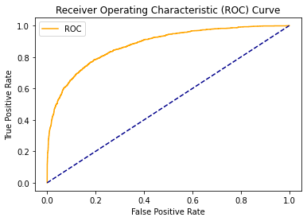

```python
y_train_pred = model.predict(X_train)

fpr, tpr, thresholds = roc_curve(y_train, y_train_pred )
print(tpr)
print(fpr)
print(thresholds)
print(roc_auc_score(y_train, y_train_pred))
optimal_idx = np.argmax(tpr - fpr)
optimal_threshold = thresholds[optimal_idx]
print("Threshold value is:", optimal_threshold)
plot_roc_curve(fpr, tpr)
```

- Setting the threshold as 0.22639003 for classifying as going to exit and not going to exit customers

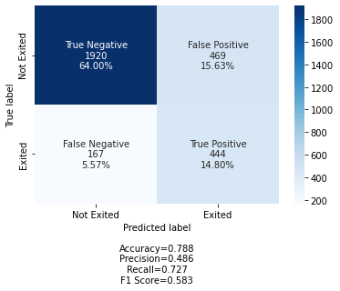

```python
## Confusion Matrix on unsee test set
import seaborn as sn
y_pred1 = model.predict(X_test)
for i in range(len(y_test)):
    if y_pred1[i]>0.22639003:
        y_pred1[i]=1
    else:
        y_pred1[i]=0



cm2=confusion_matrix(y_test, y_pred1)
labels = ['True Negative','False Positive','False Negative','True Positive']
categories = [ 'Not Exited','Exited']
make_confusion_matrix(cm2,
                      group_names=labels,
                      categories=categories,
                      cmap='Blues')
```

Detection of Exited customers did improve compared to the previous machine learning model ( Randomforest).

**Conclusion:**

We must find ways to further reduce the number of false negative.

### Model-2

#### Let's try another architecture to get the better Recall

There are some basic Hyperparameters which can help to get the better model performance.

**Early stopping:**

During training, the model is evaluated on a holdout validation dataset after each epoch. If the performance of the model on the validation dataset starts to degrade or no improvement (e.g. loss begins to increase or accuracy begins to decrease), then the training process is stopped after the certian interations.The model at the time that training is stopped is then used and is known to have good generalization performance.

This procedure is called “early stopping” and is perhaps one of the oldest and most widely used forms of neural network regularization.

**Weight Initialization**

Weight initialization is an important consideration in the design of a neural network model.

The nodes in neural networks are composed of parameters referred to as weights used to calculate a weighted sum of the inputs.

Neural network models are fit using an optimization algorithm called stochastic gradient descent that incrementally changes the network weights to minimize a loss function, hopefully resulting in a set of weights for the mode that is capable of making useful predictions.

This optimization algorithm requires a starting point in the space of possible weight values from which to begin the optimization process. Weight initialization is a procedure to set the weights of a neural network to small random values that define the starting point for the optimization (learning or training) of the neural network model.

```python
#Training Multi-layer perceptron with 2 hidden layers

#adding earlystopping callback
es= tf.keras.callbacks.EarlyStopping(monitor='val_loss',
                              min_delta=0,
                              patience=15,
                             verbose=0, mode='min', restore_best_weights= True)
Model2 = Sequential()
#Initializing the weights uisng hue_normal
Model2.add(Dense(65, input_shape=(11, ), kernel_initializer='he_normal', activation='relu'))
Model2.add(Dropout(0.5))
Model2.add(Dense(65, kernel_initializer='he_normal', activation='relu'))
Model2.add(Dropout(0.5))
Model2.add(Dense(1, kernel_initializer='he_normal', activation='sigmoid'))

Model2.compile(Adam(lr=0.001), loss='binary_crossentropy', metrics=['accuracy'])

his_mod2= Model2.fit(X_train, y_train,  batch_size=700, epochs=40, callbacks=[es], shuffle=True, verbose=1,validation_split=0.2)
```

```
Train on 5600 samples, validate on 1400 samples
```

Plotting the train and validation loss

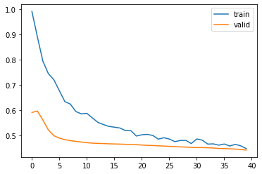

```python
# Capturing learning history per epoch
hist  = pd.DataFrame(his_mod2.history)
hist['epoch'] = his_mod2.epoch

# Plotting accuracy at different epochs
plt.plot(hist['loss'])
plt.plot(hist['val_loss'])
plt.legend(("train" , "valid") , loc =0)
```

- Getting the optimal value for threshold from the ROC curve

```
[0.00000000e+00 7.01262272e-04 1.33239832e-02 ... 9.99298738e-01
 1.00000000e+00 1.00000000e+00]
[0.         0.         0.         ... 0.99964119 0.99964119 1.        ]
[1.7182573  0.7182573  0.6184849  ... 0.00658914 0.00607836 0.00606135]
0.802873967544163
Threshold value is: 0.30883503
```

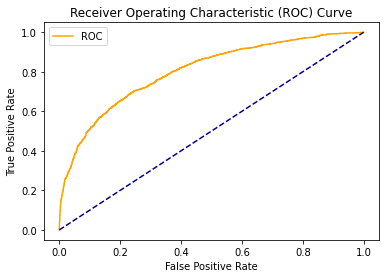

```python
y_train_pred = Model2.predict(X_train)

fpr, tpr, thresholds = roc_curve(y_train, y_train_pred )
print(tpr)
print(fpr)
print(thresholds)
print(roc_auc_score(y_train, y_train_pred))
optimal_idx = np.argmax(tpr - fpr)
optimal_threshold = thresholds[optimal_idx]
print("Threshold value is:", optimal_threshold)
plot_roc_curve(fpr, tpr)
```

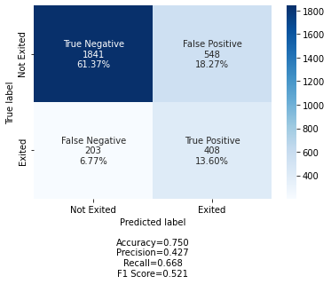

```python
## Confusion Matrix on unsee test set using the optimum threshold
import seaborn as sn
y_pred1 = Model2.predict(X_test)
for i in range(len(y_test)):
    if y_pred1[i]>0.30883503:
        y_pred1[i]=1
    else:
        y_pred1[i]=0



cm2=confusion_matrix(y_test, y_pred1)
labels = ['True Negative','False Positive','False Negative','True Positive']
categories = [ 'Not Exited','Exited']
make_confusion_matrix(cm2,
                      group_names=labels,
                      categories=categories,
                      cmap='Blues')
```

**Conclusion:**

As you can see here the Recall of the model is not improved than the Previous ANN model. It is better than RandomForest but the precision is also bad.

Let's try weighted loss for imbalance dataset

## Model3

### Weighted loss to account for large class imbalance in train dataset

- we will adjust the class imbalance by giving additional weight to the loss associated to errors made on Exited customer case

We will use our first ANN model and apply weighted loss

Let's review the process:

```python
from sklearn.utils import class_weight
class_weights = class_weight.compute_class_weight('balanced', np.unique(y_train), np.array([y_train.iloc[i] for i in range(len(y_train))]))
class_weights = dict(enumerate(class_weights))
class_weights
```

```
{0: 0.6279153211338356, 1: 2.4544179523141656}
```

- The class 'Exited' (y=1) is assigned a weight of 2.45 vs 0.6279 for the class 'Not Exited' due to the very low prevalence we detected during data exploration. This allows the model to give more importance to the errors made on fraudulent cases during training.

Training the model

```python
model.fit(X_train,y_train,batch_size=15,epochs=15, class_weight=class_weights, shuffle=True)
```

```
<tensorflow.python.keras.callbacks.History at 0x1135a6dd5c0>
```

```python
score_weighted = model.evaluate(X_test, y_test)
```

- Getting the threshold for weigted model

```
[0.         0.00140252 0.00280505 ... 0.99929874 1.         1.        ]
[0.         0.         0.         ... 0.82651597 0.82651597 1.        ]
[2.0000000e+00 1.0000000e+00 9.9999994e-01 ... 5.7313293e-02 5.7222724e-02
 5.5053830e-04]
0.9066819198130369
Threshold value is: 0.42585948
```

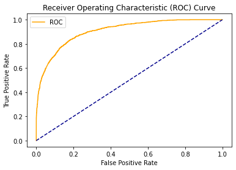

```python
y_train_predwt = model.predict(X_train)

fpr, tpr, thresholds = roc_curve(y_train, y_train_predwt )
print(tpr)
print(fpr)
print(thresholds)
print(roc_auc_score(y_train, y_train_predwt))
optimal_idx = np.argmax(tpr - fpr)
optimal_threshold = thresholds[optimal_idx]
print("Threshold value is:", optimal_threshold)
plot_roc_curve(fpr, tpr)
```

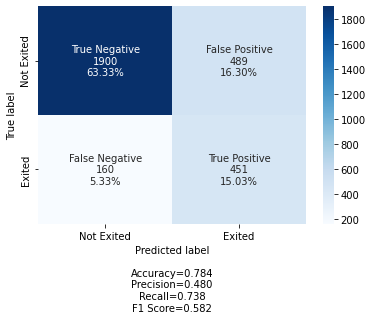

```python
## Confusion Matrix on unsee test set
import seaborn as sn
y_pred1 = model.predict(X_test)
for i in range(len(y_test)):
    if y_pred1[i]>  0.42585948:
        y_pred1[i]=1
    else:
        y_pred1[i]=0



cm2=confusion_matrix(y_test, y_pred1)
labels = ['True Negative','False Positive','False Negative','True Positive']
categories = [ 'Not Exited','Exited']
make_confusion_matrix(cm2,
                      group_names=labels,
                      categories=categories,
                      cmap='Blues')
```

- There are 611 Exiting customers in the test data and yet 160 exiting customres are not identified (false negative) which remains an issue. Our objective must be to detect as many exiting customers as possible since these can have a huge negative impact.
- 489 regular customers are detected as potentially exiting by the model. These are false positive. This number is not negligible.

**Conclusion:**

There is still scope for improvement

## Model 4

### Hyperparameter Tuning

```python
# Make scorer accuracy
score_acc = make_scorer(accuracy_score)
```

```python
# Create function
def nn_cl_bo(neurons, activation, optimizer, learning_rate,  batch_size, epochs ):
    optimizerL = ['SGD', 'Adam', 'RMSprop', 'Adadelta', 'Adagrad', 'Adamax', 'Nadam', 'Ftrl','SGD']
    optimizerD= {'Adam':Adam(lr=learning_rate), 'SGD':SGD(lr=learning_rate),
                 'RMSprop':RMSprop(lr=learning_rate), 'Adadelta':Adadelta(lr=learning_rate),
                 'Adagrad':Adagrad(lr=learning_rate), 'Adamax':Adamax(lr=learning_rate)}
    activationL = ['relu', 'sigmoid', 'softplus', 'softsign', 'tanh', 'selu',
                   'elu', 'exponential', LeakyReLU,'relu']
    neurons = round(neurons)
    activation = activationL[round(activation)]
    batch_size = round(batch_size)
    epochs = round(epochs)
    def nn_cl_fun():
        opt = Adam(lr = learning_rate)
        nn = Sequential()
        nn.add(Dense(neurons, input_dim=11, activation=activation))
        nn.add(Dense(neurons, activation=activation))
        nn.add(Dense(1, activation='sigmoid'))
        nn.compile(loss='binary_crossentropy', optimizer=opt, metrics=['accuracy'])
        return nn
    es = EarlyStopping(monitor='acc', mode='max', verbose=0, patience=20)
    nn = KerasClassifier(build_fn=nn_cl_fun, epochs=epochs, batch_size=batch_size,
                         verbose=0)
    kfold = StratifiedKFold(n_splits=5, shuffle=True, random_state=123)
    score = cross_val_score(nn, X_train, y_train, scoring=score_acc, cv=kfold, fit_params={'callbacks':[es]}).mean()
    return score
```

```python
# Set paramaters
params_nn ={
    'neurons': (10, 50),
    'activation':(0, 6),
    'optimizer':(0,7),
    'learning_rate':(0.01, 0.5),
    'batch_size':(10, 60),
    'epochs':(20, 60)
}
# Run Bayesian Optimization
nn_bo = BayesianOptimization(nn_cl_bo, params_nn, random_state=111)
nn_bo.maximize(init_points=25, n_iter=4)
```

```
|   iter    |  target   | activa... | batch_... |  epochs   | learni... |  neurons  | optimizer |
-------------------------------------------------------------------------------------------------
|  1        |  0.7687   |  3.673    |  18.45    |  37.44    |  0.3869   |  21.81    |  1.044    |
|  2        |  0.7963   |  0.1349   |  31.01    |  29.55    |  0.1755   |  49.63    |  1.664    |
|  3        |  0.8103   |  0.4872   |  43.48    |  44.85    |  0.1444   |  28.65    |  0.8286   |
|  4        |  0.7963   |  0.4437   |  55.04    |  51.76    |  0.4219   |  42.61    |  6.937    |
|  5        |  0.8411   |  3.464    |  50.69    |  36.85    |  0.02345  |  28.17    |  0.7373   |
|  6        |  0.7963   |  4.903    |  44.89    |  42.61    |  0.1444   |  49.94    |  0.9663   |
|  7        |  0.7714   |  3.692    |  34.25    |  36.2     |  0.3666   |  22.91    |  2.804    |
|  8        |  0.808    |  1.914    |  57.36    |  56.75    |  0.4088   |  11.36    |  6.604    |
|  9        |  0.6777   |  5.703    |  50.33    |  39.25    |  0.4837   |  26.68    |  2.232    |
|  10       |  0.8451   |  0.09866  |  11.91    |  22.12    |  0.0727   |  11.34    |  1.585    |
|  11       |  0.8221   |  3.263    |  18.93    |  27.17    |  0.08331  |  37.32    |  3.283    |
|  12       |  0.6776   |  4.609    |  43.44    |  37.65    |  0.3017   |  28.47    |  6.743    |
|  13       |  0.8094   |  0.8869   |  55.34    |  39.92    |  0.3003   |  37.39    |  1.242    |
|  14       |  0.7963   |  5.188    |  34.1     |  22.77    |  0.1887   |  24.46    |  3.304    |
|  15       |  0.8267   |  1.077    |  18.76    |  57.97    |  0.3313   |  15.4     |  6.495    |
|  16       |  0.7963   |  5.051    |  12.64    |  28.15    |  0.4375   |  36.95    |  2.081    |
|  17       |  0.7857   |  4.406    |  40.92    |  28.42    |  0.403    |  12.36    |  2.158    |
|  18       |  0.8284   |  1.244    |  58.61    |  56.38    |  0.3415   |  14.61    |  6.706    |
|  19       |  0.8441   |  0.5503   |  41.49    |  56.12    |  0.1765   |  36.11    |  6.476    |
|  20       |  0.8131   |  2.244    |  48.57    |  55.85    |  0.3139   |  16.04    |  2.624    |
|  21       |  0.8003   |  3.815    |  32.95    |  41.29    |  0.1826   |  36.39    |  3.336    |
|  22       |  0.807    |  2.728    |  16.24    |  36.5     |  0.1438   |  23.87    |  6.821    |
|  23       |  0.793    |  1.293    |  44.14    |  21.27    |  0.4193   |  38.07    |  6.762    |
|  24       |  0.8343   |  3.551    |  20.87    |  48.77    |  0.02513  |  26.75    |  1.969    |
|  25       |  0.8411   |  0.6375   |  31.32    |  53.62    |  0.0641   |  49.47    |  1.633    |
|  26       |  0.7116   |  2.682    |  19.48    |  27.3     |  0.4114   |  36.8     |  2.97     |
|  27       |  0.7961   |  2.482    |  23.27    |  41.03    |  0.4897   |  39.97    |  4.245    |
|  28       |  0.6894   |  1.159    |  59.82    |  34.49    |  0.4005   |  26.43    |  6.493    |
|  29       |  0.7963   |  5.78     |  49.25    |  35.51    |  0.42     |  30.34    |  6.071    |
=================================================================================================
```

```python
params_nn_ = nn_bo.max['params']
activationL = ['relu', 'sigmoid', 'softplus', 'softsign', 'tanh', 'selu',
               'elu', 'exponential', LeakyReLU,'relu']
params_nn_['activation'] = activationL[round(params_nn_['activation'])]
params_nn_
```

```
{'activation': 'relu',
 'batch_size': 11.909096284173689,
 'epochs': 22.123586017799603,
 'learning_rate': 0.07270079917239038,
 'neurons': 11.33532637829019,
 'optimizer': 1.5849476467967452}
```

```python
opt = Adam(lr = 0.07270079917239038)
nn_opt = Sequential()
nn_opt.add(Dense(11.33532637829019, input_dim=11, activation='selu'))
nn_opt.add(Dense(11.33532637829019, activation='selu'))
nn_opt.add(Dense(1, activation='sigmoid'))
nn_opt.compile(loss='binary_crossentropy', optimizer=opt, metrics=['accuracy'])
```

```python
#fitting the model
history=nn_opt.fit(X_train,y_train,batch_size=12,epochs=22,validation_split=0.2)
```

```
Train on 5600 samples, validate on 1400 samples
```

```
[0.         0.02875175 0.03015428 ... 1.         1.         1.        ]
[0.         0.         0.         ... 0.9917474  0.99820596 1.        ]
[2.0000000e+00 1.0000000e+00 9.9999988e-01 ... 5.3459406e-04 3.2782555e-07
 0.0000000e+00]
0.8368278815035344
Threshold value is: 0.13288358
```

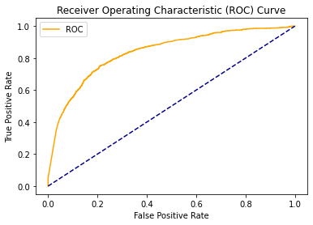

```python
y_train_pred = nn_opt.predict(X_train)

fpr, tpr, thresholds = roc_curve(y_train, y_train_pred )
print(tpr)
print(fpr)
print(thresholds)
print(roc_auc_score(y_train, y_train_pred))
optimal_idx = np.argmax(tpr - fpr)
optimal_threshold = thresholds[optimal_idx]
print("Threshold value is:", optimal_threshold)
plot_roc_curve(fpr, tpr)
```

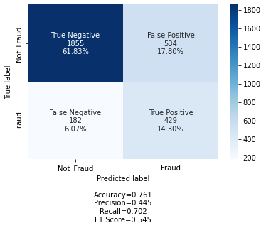

```python
y_predopt = nn_opt.predict(X_test)
for i in range(len(y_test)):
    if y_predopt[i]>0.13288358:
        y_predopt[i]=1
    else:
        y_predopt[i]=0



cm2=confusion_matrix(y_test, y_predopt)
labels = ['True Negative','False Positive','False Negative','True Positive']
categories = [ 'Not_Fraud','Fraud']
make_confusion_matrix(cm2,
                      group_names=labels,
                      categories=categories,
                      cmap='Blues')
```

- The recall is not improved more than the weighted model3 . In fact it is less than the weighted class model.

## Model comparison

```python
# defining list of models
models = ['Basic_Neural_Network','Neural_Network_with_Early_stopping','Basic_Neural_Network_with_weigted_classes','Hypertuned_Neural_network']

# defining empty lists to add train and test results

acc_test = []
recall_test = []
precision_test = []
F1_score_test = []

# Metrics for basic nueral network
acc_test.append(0.788)
precision_test.append(0.486)
recall_test.append(0.727)
F1_score_test.append(0.583)

# Neural Network with Early stopping
acc_test.append(0.750)
precision_test.append(0.427)
recall_test.append(0.668)
F1_score_test.append(0.521)

# Neural Network with weigted classes
acc_test.append(0.784)
precision_test.append(0.480)
recall_test.append(0.738)
F1_score_test.append(0.582)

# Hyper Tuned neural network
acc_test.append(0.761)
precision_test.append(0.445)
recall_test.append(0.702)
F1_score_test.append(0.545)

comparison_frame = pd.DataFrame({'Model':['Basic Neural Network','Neural Network with Early stopping','Basic Neural Network with weigted classes','Hypertuned Neural network'],
                                          'Test_Accuracy': acc_test,
                                          'Test_Recall':recall_test,
                                          'Test_Precision':precision_test,
                                           'Test_F1_score':F1_score_test})
comparison_frame
```

|  | Model | Test_Accuracy | Test_Recall | Test_Precision | Test_F1_score |
| --- | --- | --- | --- | --- | --- |
| 0 | Basic Neural Network | 0.788 | 0.727 | 0.486 | 0.583 |
| 1 | Neural Network with Early stopping | 0.750 | 0.668 | 0.427 | 0.521 |
| 2 | Basic Neural Network with weigted classes | 0.784 | 0.738 | 0.480 | 0.582 |
| 3 | Hypertuned Neural network | 0.761 | 0.702 | 0.445 | 0.545 |

- As can be seen from the metrices of all the models the model Neural Network model with weighted classes has the highest recall of 0.738. Our performance evaluation metric is Recall. This model also has 2nd highest accuracy and precision.
- Based on this the final model is the neural network with weighted classes.

## Conclusion

As you can see here the Recall is increased but the precision is very bad. There is still lot of scope of improvements as follows:

1) Resampling techniques can be applied to balanced the data and then train the model

2) Hyperparameter tuning can be applied to the layers

We can select the Model with weigted class as the final model

### Business Recommendations

- There is relatively very less correlation between the attributes.
- Older customers tend to exit the bank. Bank needs to give more interest related to senior citizens or introduce some schemes to retain them.
- High balance customers tend a bit to leave the bank. Bank should give quarterly bonus or waive any fees for high balance customers to retain them.
- More customers who are not active members tend to exit.
- Customers having number 4 product almost every one has exited. Bank should try to revamp that product or change it or review it.
- Bank should focus more on german customers as they tend to leave. Maybe more services in german language must be offered.